# **GISMA UNIVERISTY OF APPLIED SCIENCES , POTSDAM , GERMANY**

# **Instructor Name** : Prof. Dr. Mohammad Mahdavi

# **Module** : M606 Machine Learning

# **Student Name** : AWAIS RAFI

# **Student ID** : GH1024169

# **Submission Date** : September 21,2023

**The objective of this Data Analysis Project is to predict whether a Person will be diagnosed with Heart Disease or not using several factors that effect the diagnosis such as alcohol consumption,potatoe consumption and several other factors.**

**The Project will extensively use Machine learning Library ScikitLearn and DataFrame management Library Pandas**

**Following are the several Libraries that would be Imported and Used**

[figure not shown]

```python
from sklearn.compose import ColumnTransformer

from sklearn.preprocessing import OrdinalEncoder

import sklearn.model_selection

from sklearn.pipeline import Pipeline

from sklearn.pipeline import make_pipeline

###############################################
from sklearn.preprocessing import OneHotEncoder

from sklearn.preprocessing import StandardScaler

from sklearn.preprocessing import OrdinalEncoder

##############################################
from sklearn import metrics
###############################################
from sklearn.preprocessing import FunctionTransformer
from sklearn.linear_model import LogisticRegression
from sklearn.svm import SVC
from sklearn.tree import DecisionTreeClassifier
from sklearn.ensemble import RandomForestClassifier

################################################
import seaborn as snss
import matplotlib.pyplot as plts

#############################################
from sklearn.neighbors import KNeighborsClassifier
from sklearn.naive_bayes import GaussianNB
from imblearn.over_sampling import SMOTE
from sklearn.model_selection import GridSearchCV


import pandas as pdss
```

# **Data Collection**

**The Dataset under Analysis is Imported**

```python
df = pdss.read_csv("/content/CardoVascularDiseaseDataSet.csv")
```

# **Data Exploration**

**Data will be explored to find any missing Explicit,Implicit values and Data Visualization tool will be used to understand data and look for any skewness or anamoly**

```python
df.head()
```

|  | General_Health | Checkup | Exercise | Heart_Disease | Skin_Cancer | Other_Cancer | Depression | Diabetes | Arthritis | Sex | Age_Category | Height_(cm) | Weight_(kg) | BMI | Smoking_History | Alcohol_Consumption | Fruit_Consumption | Green_Vegetables_Consumption | FriedPotato_Consumption |
| --- | --- | --- | --- | --- | --- | --- | --- | --- | --- | --- | --- | --- | --- | --- | --- | --- | --- | --- | --- |
| 0 | Poor | Within the past 2 years | No | No | No | No | No | No | Yes | Female | 70-74 | 150.0 | 32.66 | 14.54 | Yes | 0.0 | 30.0 | 16.0 | 12.0 |
| 1 | Very Good | Within the past year | No | Yes | No | No | No | Yes | No | Female | 70-74 | 165.0 | 77.11 | 28.29 | No | 0.0 | 30.0 | 0.0 | 4.0 |
| 2 | Very Good | Within the past year | Yes | No | No | No | No | Yes | No | Female | 60-64 | 163.0 | 88.45 | 33.47 | No | 4.0 | 12.0 | 3.0 | 16.0 |
| 3 | Poor | Within the past year | Yes | Yes | No | No | No | Yes | No | Male | 75-79 | 180.0 | 93.44 | 28.73 | No | 0.0 | 30.0 | 30.0 | 8.0 |
| 4 | Good | Within the past year | No | No | No | No | No | No | No | Male | 80+ | 191.0 | 88.45 | 24.37 | Yes | 0.0 | 8.0 | 4.0 | 0.0 |

**Having a Look at the Dataset it can be noticed that the dataSet has categoricl and Numerical Columns , hence the data has to be Encoded using several Encoding technqiues - they will be used later on**

```python
df.tail()
```

|  | General_Health | Checkup | Exercise | Heart_Disease | Skin_Cancer | Other_Cancer | Depression | Diabetes | Arthritis | Sex | Age_Category | Height_(cm) | Weight_(kg) | BMI | Smoking_History | Alcohol_Consumption | Fruit_Consumption | Green_Vegetables_Consumption | FriedPotato_Consumption |
| --- | --- | --- | --- | --- | --- | --- | --- | --- | --- | --- | --- | --- | --- | --- | --- | --- | --- | --- | --- |
| 308849 | Very Good | Within the past year | Yes | No | No | No | No | No | No | Male | 25-29 | 168.0 | 81.65 | 29.05 | No | 4.0 | 30.0 | 8.0 | 0.0 |
| 308850 | Fair | Within the past 5 years | Yes | No | No | No | No | Yes | No | Male | 65-69 | 180.0 | 69.85 | 21.48 | No | 8.0 | 15.0 | 60.0 | 4.0 |
| 308851 | Very Good | 5 or more years ago | Yes | No | No | No | Yes | Yes, but female told only during pregnancy | No | Female | 30-34 | 157.0 | 61.23 | 24.69 | Yes | 4.0 | 40.0 | 8.0 | 4.0 |
| 308852 | Very Good | Within the past year | Yes | No | No | No | No | No | No | Male | 65-69 | 183.0 | 79.38 | 23.73 | No | 3.0 | 30.0 | 12.0 | 0.0 |
| 308853 | Excellent | Within the past year | Yes | No | No | No | No | No | No | Female | 45-49 | 160.0 | 81.19 | 31.71 | No | 1.0 | 5.0 | 12.0 | 1.0 |

```python
df.info()
```

```
<class 'pandas.core.frame.DataFrame'>
RangeIndex: 308854 entries, 0 to 308853
Data columns (total 19 columns):
 #   Column                        Non-Null Count   Dtype
---  ------                        --------------   -----
 0   General_Health                308854 non-null  object
 1   Checkup                       308854 non-null  object
 2   Exercise                      308854 non-null  object
 3   Heart_Disease                 308854 non-null  object
 4   Skin_Cancer                   308854 non-null  object
 5   Other_Cancer                  308854 non-null  object
 6   Depression                    308854 non-null  object
 7   Diabetes                      308854 non-null  object
 8   Arthritis                     308854 non-null  object
 9   Sex                           308854 non-null  object
 10  Age_Category                  308854 non-null  object
 11  Height_(cm)                   308854 non-null  float64
 12  Weight_(kg)                   308854 non-null  float64
 13  BMI                           308854 non-null  float64
 14  Smoking_History               308854 non-null  object
 15  Alcohol_Consumption           308854 non-null  float64
 16  Fruit_Consumption             308854 non-null  float64
 17  Green_Vegetables_Consumption  308854 non-null  float64
 18  FriedPotato_Consumption       308854 non-null  float64
dtypes: float64(7), object(12)
memory usage: 44.8+ MB
```

**Using df.info() provides us with the several Data types present and also gives us if the dataset has any null or non-null value**

```python
df.describe()
```

|  | Height_(cm) | Weight_(kg) | BMI | Alcohol_Consumption | Fruit_Consumption | Green_Vegetables_Consumption | FriedPotato_Consumption |
| --- | --- | --- | --- | --- | --- | --- | --- |
| count | 308854.000000 | 308854.000000 | 308854.000000 | 308854.000000 | 308854.000000 | 308854.000000 | 308854.000000 |
| mean | 170.615249 | 83.588655 | 28.626211 | 5.096366 | 29.835200 | 15.110441 | 6.296616 |
| std | 10.658026 | 21.343210 | 6.522323 | 8.199763 | 24.875735 | 14.926238 | 8.582954 |
| min | 91.000000 | 24.950000 | 12.020000 | 0.000000 | 0.000000 | 0.000000 | 0.000000 |
| 25% | 163.000000 | 68.040000 | 24.210000 | 0.000000 | 12.000000 | 4.000000 | 2.000000 |
| 50% | 170.000000 | 81.650000 | 27.440000 | 1.000000 | 30.000000 | 12.000000 | 4.000000 |
| 75% | 178.000000 | 95.250000 | 31.850000 | 6.000000 | 30.000000 | 20.000000 | 8.000000 |
| max | 241.000000 | 293.020000 | 99.330000 | 30.000000 | 120.000000 | 128.000000 | 128.000000 |

The df.describe() provides us with further analyis of the data such as Count , mean , std and several other attributes.

**Seaborn Library will be used for further Data Visualization analysis**

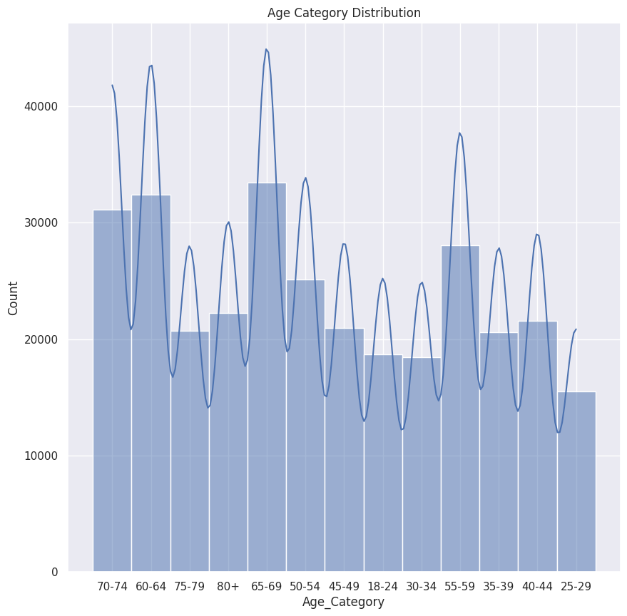

```python
Age_Category = df['Age_Category']
snss.set_theme(style="darkgrid")
plts.figure(figsize = (10,10))
snss.histplot(data = df, x = Age_Category ,kde = True, bins = 40 ,  color = 'b')
plts.title('Age Category Distribution')
plts.show()
```

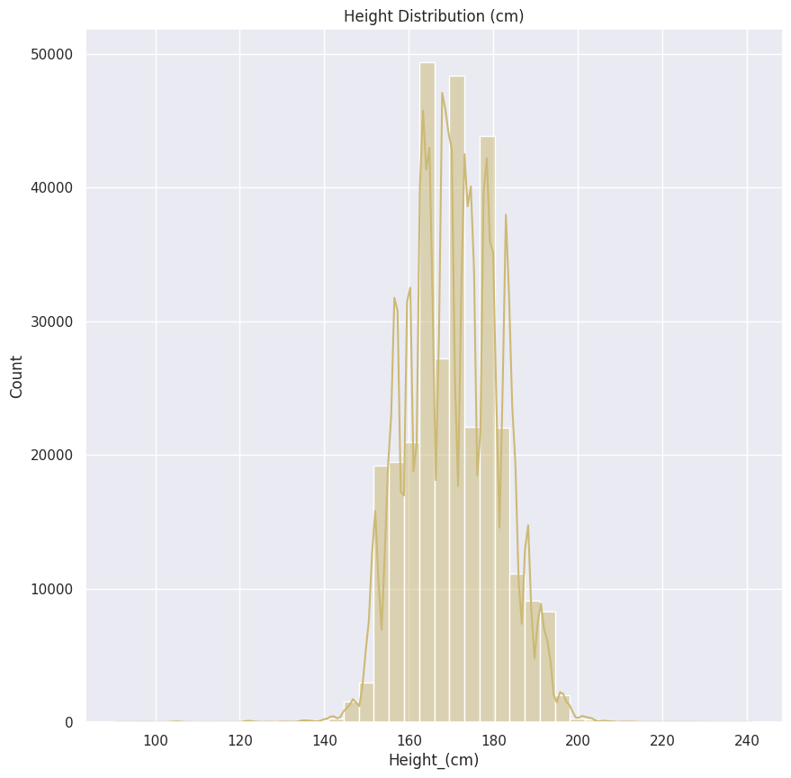

```python
Height_cm = df['Height_(cm)']
snss.set_theme(style="darkgrid")
plts.figure(figsize = (10,10))
snss.histplot(data = df, x = Height_cm ,kde = True ,bins = 42 ,color = 'y')
plts.title('Height Distribution (cm)')
plts.show()
```

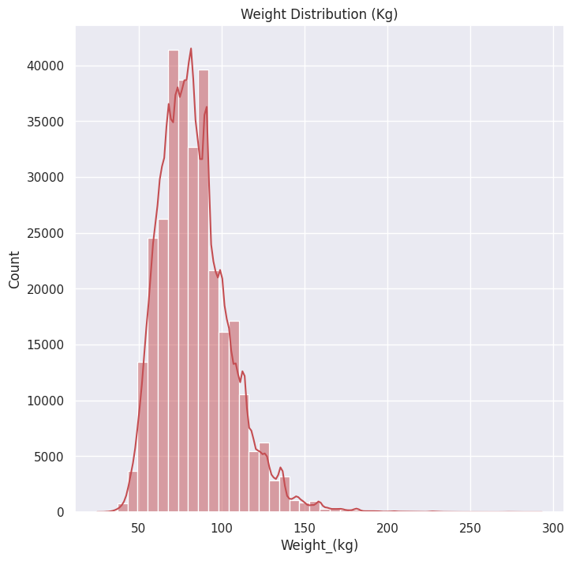

```python
Weight_Kg = df['Weight_(kg)']
snss.set_theme(style="darkgrid")
plts.figure(figsize = (8,8))
snss.histplot(data = df, x = Weight_Kg ,kde = True ,bins = 44 ,  color = 'r')
plts.title('Weight Distribution (Kg)')
plts.show()
```

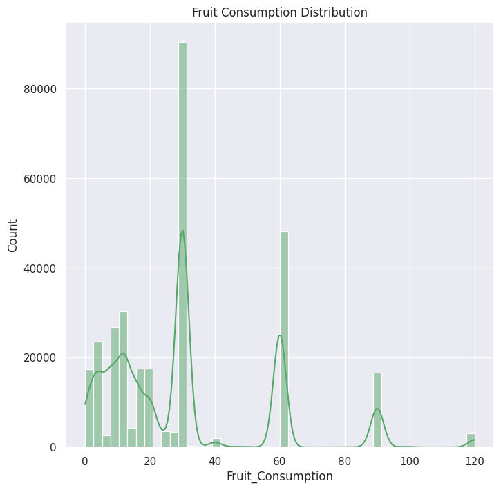

```python
Fruit_Consumption = df['Fruit_Consumption']
snss.set_theme(style="darkgrid")
plts.figure(figsize = (8,8))
snss.histplot(data = df, x = Fruit_Consumption,kde = True, bins = 46 ,  color = 'g')
plts.title('Fruit Consumption Distribution')
plts.show()
```

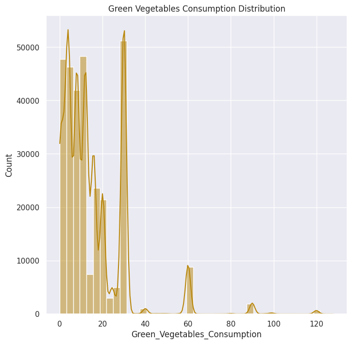

```python
Green_Vegetables_Consumption = df['Green_Vegetables_Consumption']
snss.set_theme(style="darkgrid")
plts.figure(figsize = (8,8))
snss.histplot(data = df, x = Green_Vegetables_Consumption, kde = True ,bins = 41,color = 'darkgoldenrod')
plts.title('Green Vegetables Consumption Distribution')
plts.show()
```

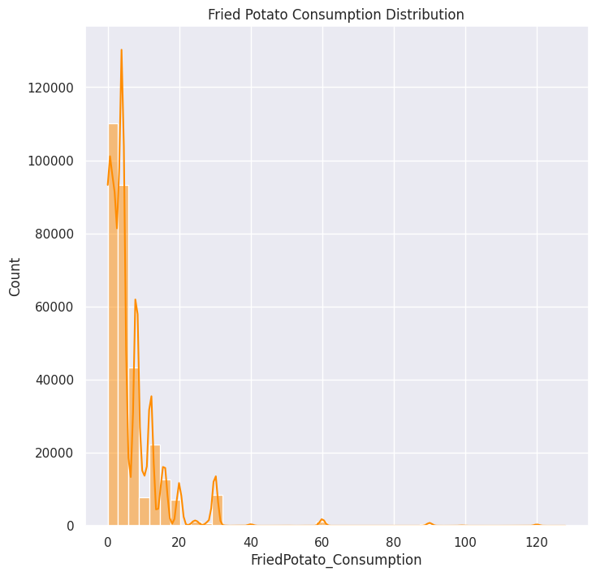

```python
FriedPotato_Consumption = df['FriedPotato_Consumption']
snss.set_theme(style="darkgrid")
plts.figure(figsize = (8,8))
snss.histplot(data = df, x = FriedPotato_Consumption , kde = True , bins = 44 ,color = 'darkorange')
plts.title('Fried Potato Consumption Distribution')
plts.show()
```

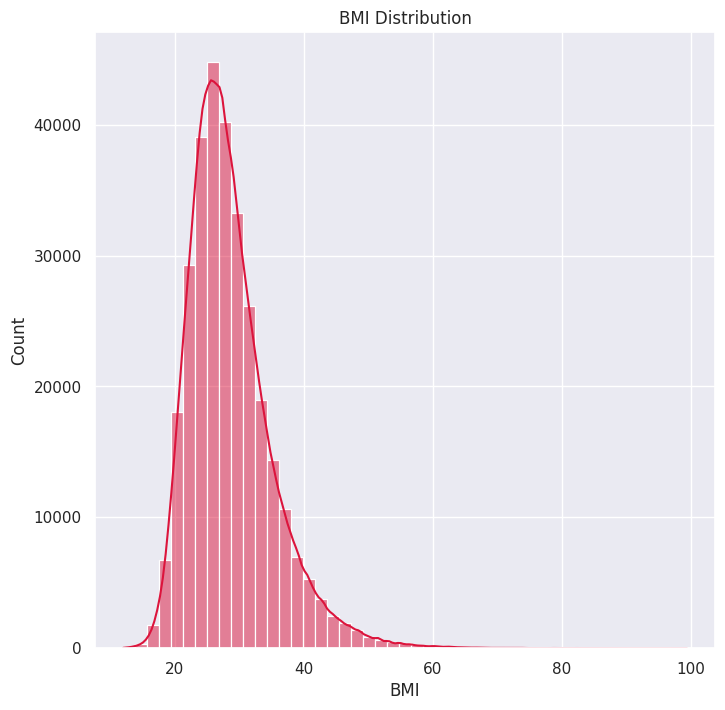

```python
BMI = df['BMI']
snss.set_theme(style="darkgrid")
plts.figure(figsize = (8,8))
snss.histplot(data = df, x = BMI ,kde = True , bins = 47 , color = 'crimson')
plts.title('BMI Distribution')
plts.show()
```

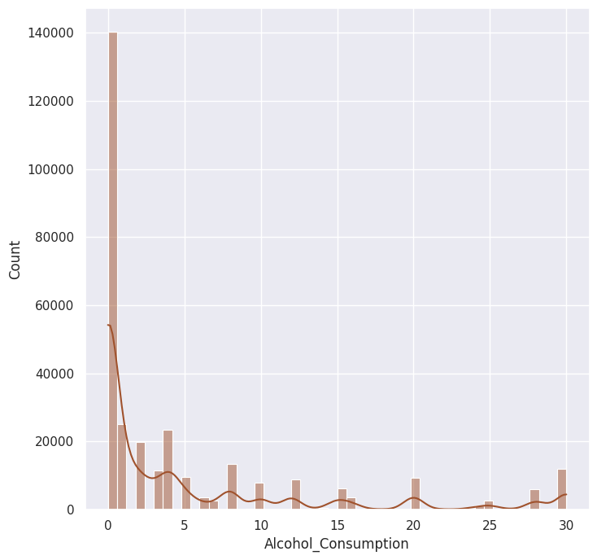

```python
Alcohol_Consumption = df['Alcohol_Consumption']
snss.set_theme(style="darkgrid")
plts.figure(figsize = (8,8))
snss.histplot(data = df, x = Alcohol_Consumption,kde = True , bins = 50 , color = 'sienna')
```

**As it can be seen that a large Portion Of the Numerical DataSet is highlyskewed towards the left of the centre** **Therefor as a result Data Scaling tools have to be used to refine the data for further processing**

**The dataset will be categorized into Numerical and Categorical Columns as to ease further processing**

```python
numerical_datacolumns = df.select_dtypes(include=['float64']).columns.sort_values()

print("The Numerical Data Columns are as follows : ",numerical_datacolumns)
```

```
The Numerical Data Columns are as follows :  Index(['Alcohol_Consumption', 'BMI', 'FriedPotato_Consumption',
       'Fruit_Consumption', 'Green_Vegetables_Consumption', 'Height_(cm)',
       'Weight_(kg)'],
      dtype='object')
```

```python
categorical_datacolumns =df.select_dtypes(include=['object']).columns.sort_values()

print("The Categorical Data Columns are as follows : ",categorical_datacolumns)
```

```
The Categorical Data Columns are as follows :  Index(['Age_Category', 'Arthritis', 'Checkup', 'Depression', 'Diabetes',
       'Exercise', 'General_Health', 'Heart_Disease', 'Other_Cancer', 'Sex',
       'Skin_Cancer', 'Smoking_History'],
      dtype='object')
```

# **Data Preprocessing**

**The target Variable is Heart Disease since the Data is either Yes OR No the entries will be mapped to 0 and 1 for further Processing however for the assignment such a approach wont be used and is only an alternative as OneHotencoding technque encodes all the dataset that has been split into test and train**

**A approach exists to map the Data under the Target Column however for this project it wont be used as incases it is irrelevant as Onehotencoding eventually encodes the target variable as well**

**Following is the code for the Mapping**

df['Heart_Disease'] = df['Heart_Disease'].map({'Yes':1,'No':0})

**The Dataset will be split into test and Train for further Processing**

```python
df_train , df_test = sklearn.model_selection.train_test_split(df)
```

```python
x_train = df_train.drop(["Heart_Disease"],axis=1)
y_train = df_train["Heart_Disease"]
x_test  = df_test.drop(["Heart_Disease"],axis=1)
y_test  = df_test["Heart_Disease"]

print("The following are Respective Row and Column Size/Entries ")
print("The Row and Column size  of x_train is " , x_train.shape)
print("The Row and Column size of x_test is  ",x_test.shape)
```

```
The following are Respective Row and Column Size/Entries
The Row and Column size  of x_train is  (231640, 18)
The Row and Column size of x_test is   (77214, 18)
```

**To check for any Null Values inthe DataSet**

```python
x_train.isnull()
```

|  | General_Health | Checkup | Exercise | Skin_Cancer | Other_Cancer | Depression | Diabetes | Arthritis | Sex | Age_Category | Height_(cm) | Weight_(kg) | BMI | Smoking_History | Alcohol_Consumption | Fruit_Consumption | Green_Vegetables_Consumption | FriedPotato_Consumption |
| --- | --- | --- | --- | --- | --- | --- | --- | --- | --- | --- | --- | --- | --- | --- | --- | --- | --- | --- |
| 85691 | False | False | False | False | False | False | False | False | False | False | False | False | False | False | False | False | False | False |
| 83203 | False | False | False | False | False | False | False | False | False | False | False | False | False | False | False | False | False | False |
| 161767 | False | False | False | False | False | False | False | False | False | False | False | False | False | False | False | False | False | False |
| 179916 | False | False | False | False | False | False | False | False | False | False | False | False | False | False | False | False | False | False |
| 164788 | False | False | False | False | False | False | False | False | False | False | False | False | False | False | False | False | False | False |
| ... | ... | ... | ... | ... | ... | ... | ... | ... | ... | ... | ... | ... | ... | ... | ... | ... | ... | ... |
| 66471 | False | False | False | False | False | False | False | False | False | False | False | False | False | False | False | False | False | False |
| 200658 | False | False | False | False | False | False | False | False | False | False | False | False | False | False | False | False | False | False |
| 65321 | False | False | False | False | False | False | False | False | False | False | False | False | False | False | False | False | False | False |
| 188337 | False | False | False | False | False | False | False | False | False | False | False | False | False | False | False | False | False | False |
| 275920 | False | False | False | False | False | False | False | False | False | False | False | False | False | False | False | False | False | False |

231640 rows × 18 columns

```python
x_test.isnull()
```

|  | General_Health | Checkup | Exercise | Skin_Cancer | Other_Cancer | Depression | Diabetes | Arthritis | Sex | Age_Category | Height_(cm) | Weight_(kg) | BMI | Smoking_History | Alcohol_Consumption | Fruit_Consumption | Green_Vegetables_Consumption | FriedPotato_Consumption |
| --- | --- | --- | --- | --- | --- | --- | --- | --- | --- | --- | --- | --- | --- | --- | --- | --- | --- | --- |
| 174560 | False | False | False | False | False | False | False | False | False | False | False | False | False | False | False | False | False | False |
| 210230 | False | False | False | False | False | False | False | False | False | False | False | False | False | False | False | False | False | False |
| 97510 | False | False | False | False | False | False | False | False | False | False | False | False | False | False | False | False | False | False |
| 94922 | False | False | False | False | False | False | False | False | False | False | False | False | False | False | False | False | False | False |
| 140239 | False | False | False | False | False | False | False | False | False | False | False | False | False | False | False | False | False | False |
| ... | ... | ... | ... | ... | ... | ... | ... | ... | ... | ... | ... | ... | ... | ... | ... | ... | ... | ... |
| 246553 | False | False | False | False | False | False | False | False | False | False | False | False | False | False | False | False | False | False |
| 133278 | False | False | False | False | False | False | False | False | False | False | False | False | False | False | False | False | False | False |
| 242885 | False | False | False | False | False | False | False | False | False | False | False | False | False | False | False | False | False | False |
| 178358 | False | False | False | False | False | False | False | False | False | False | False | False | False | False | False | False | False | False |
| 89375 | False | False | False | False | False | False | False | False | False | False | False | False | False | False | False | False | False | False |

77214 rows × 18 columns

**As it can be seen there are NoNull Explicit Values in the Dataset**

**Several Pipelines will be created to deal with ordinal,categorical and Numerical Data to help in further processing**

**Since we are dealing with Numerical Data that is highly skewed we will employ Standard Scaler method to normalize data distribution as seen above through visualization of the Data**

**Method 1 - Pipeline with Standard Scaler only**

```python
Categorical_Pipeline_column = ['Arthritis', 'Depression', 'Diabetes','Exercise', 'Other_Cancer', 'Sex','Skin_Cancer', 'Smoking_History']
```

```python
Categorical_ppln_encoding = make_pipeline(OneHotEncoder(handle_unknown='ignore'))
```

```python
Numerical_ppln_encoding = make_pipeline(StandardScaler())
```

```python
Numerical_ppln_Column = numerical_datacolumns
```

```python
AgeCategory_ppln = make_pipeline(OrdinalEncoder())
```

```python
General_Health_ppln = make_pipeline(OrdinalEncoder(categories=[['Poor','Fair','Good','Very Good','Excellent']]))
```

```python
Checkup_ppln = make_pipeline(OrdinalEncoder(categories=[['Within the past 5 years','Never','5 or more years ago','Within the past 2 years','Within the past year']]))
```

```python
Column_Tansformation = ColumnTransformer([
('Numerical Column', Numerical_ppln_encoding , Numerical_ppln_Column),
('Categorical Column',Categorical_ppln_encoding,Categorical_Pipeline_column),
('General Health Column',General_Health_ppln,['General_Health']),
('Age Category Column',AgeCategory_ppln,['Age_Category']),
('Checkup Column',Checkup_ppln,['Checkup'])])

Column_Tansformation
```

```
ColumnTransformer(transformers=[('Numerical Column',
                                 Pipeline(steps=[('standardscaler',
                                                  StandardScaler())]),
                                 Index(['Alcohol_Consumption', 'BMI', 'FriedPotato_Consumption',
       'Fruit_Consumption', 'Green_Vegetables_Consumption', 'Height_(cm)',
       'Weight_(kg)'],
      dtype='object')),
                                ('Categorical Column',
                                 Pipeline(steps=[('onehotencoder',
                                                  OneHotEncoder(handle_unknown='ign...
                                                                              'Excellent']]))]),
                                 ['General_Health']),
                                ('Age Category Column',
                                 Pipeline(steps=[('ordinalencoder',
                                                  OrdinalEncoder())]),
                                 ['Age_Category']),
                                ('Checkup Column',
                                 Pipeline(steps=[('ordinalencoder',
                                                  OrdinalEncoder(categories=[['Within '
                                                                              'the '
                                                                              'past '
                                                                              '5 '
                                                                              'years',
                                                                              'Never',
                                                                              '5 '
                                                                              'or '
                                                                              'more '
                                                                              'years '
                                                                              'ago',
                                                                              'Within '
                                                                              'the '
                                                                              'past '
                                                                              '2 '
                                                                              'years',
                                                                              'Within '
                                                                              'the '
                                                                              'past '
                                                                              'year']]))]),
                                 ['Checkup'])])
```

# **Model Training**

```python
x_train_fit =  Column_Tansformation.fit_transform(x_train)
x_test_fit  =  Column_Tansformation.fit_transform(x_test)

print("The Rows and Columns for x_train_fit is as follows",x_train_fit.shape)
print("The Rows and Columns for x_train_fit is as follows",x_test_fit.shape)
```

```
The Rows and Columns for x_train_fit is as follows (231640, 28)
The Rows and Columns for x_train_fit is as follows (77214, 28)
```

**The next step is to use Classification Algoirthms and tune hypermeters and find the best possible solution**

**(Algorithm 1) --- Using Logistic Regression Algorithm**

```python
model = sklearn.linear_model.LogisticRegression(penalty='l2',solver='newton-cg',max_iter=4000)
model.fit(x_train_fit,y_train)
```

```
LogisticRegression(max_iter=4000, solver='newton-cg')
```

```python
y_prdct = model.predict(x_test_fit)
accuracy_logistic_regression = sklearn.metrics.accuracy_score(y_test ,y_prdct)
print("The Accuracy for Logistic Regression using a solver and penalty is :",accuracy_logistic_regression)
```

```
The Accuracy for Logistic Regression using a solver and penalty is : 0.9198072888336312
```

**(Algorithm 2) -- Using Decision Tree Classifier**

```python
test_grid = {
"min_samples_split" : range(2,5,10),
"criterion" : ['gini','log_loss','entropy'],
"max_depth" : range(5,10,15)

}

Dic_classifier_model = sklearn.model_selection.GridSearchCV(sklearn.tree.DecisionTreeClassifier(),test_grid,scoring='accuracy',cv=4,n_jobs=-1)
Dic_classifier_model.fit(x_train_fit,y_train)
print("The best score using Hyperparamtre tuning of the model is as follows:",format(Dic_classifier_model.best_score_))
print("The best parameter using Hyperparamtre tuning of the model is as follows:",format(Dic_classifier_model.best_params_))
```

```
The best score using Hyperparamtre tuning of the model is as follows: 0.9189086513555517
The best parameter using Hyperparamtre tuning of the model is as follows: {'criterion': 'log_loss', 'max_depth': 5, 'min_samples_split': 2}
```

```
The accuracy using Decision Tree Classifier is 0.9199108969875929
The precision using Decision Tree Classifier is [0.92222512 0.52863436]
The recall using Decision Tree Classifier is [0.99698609 0.03864734]
The fscore using Decision Tree Classifier is [0.95814948 0.07202881]
The confusion Matrix using Decision Tree Classifier is [[70790  5970]
 [  214   240]]
```

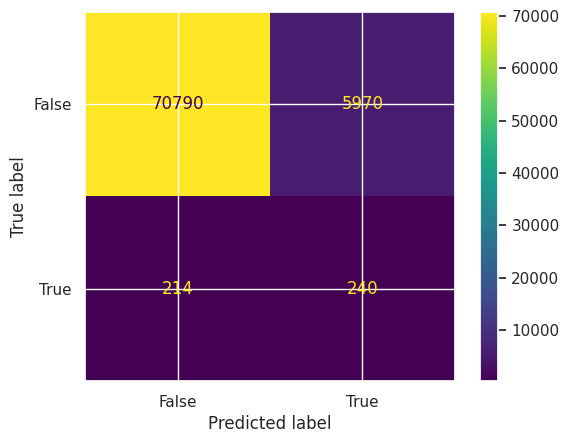

```python
y_predct = Dic_classifier_model.predict(x_test_fit)
accuracy = sklearn.metrics.accuracy_score(y_predct,y_test)
conf_mtrx = sklearn.metrics.confusion_matrix(y_predct,y_test)

precision,recall,fscore,support= sklearn.metrics.precision_recall_fscore_support(y_test,y_predct)
print("The accuracy using Decision Tree Classifier is",accuracy)
print("The precision using Decision Tree Classifier is",precision)
print("The recall using Decision Tree Classifier is",recall)
print("The fscore using Decision Tree Classifier is",fscore)
print("The confusion Matrix using Decision Tree Classifier is",conf_mtrx)


conf_matrix_dsply = metrics.ConfusionMatrixDisplay(confusion_matrix = conf_mtrx, display_labels = [False, True])
conf_matrix_dsply.plot()
plts.show()
```

**(Algorithm 3) -- Using Random Forest Classifier**

```python
random_frst = RandomForestClassifier()
random_frst.fit(x_train_fit,y_train)
y_prd = random_frst.predict(x_test_fit)
```

```python
accry_randomforest = sklearn.metrics.accuracy_score(y_test,y_prd)
print("The Accuracy Using Random Forest Classifier is",accry_randomforest)
```

```
The Accuracy Using Random Forest Classifier is 0.9182661175434507
```

```python
test_grid_1 = {
"min_samples_split" : range(2,5,10),
"max_depth" : range(5,10,15),
"criterion" : ['gini','log_loss','entropy']
}

random_classifier_model = sklearn.model_selection.GridSearchCV(sklearn.ensemble.RandomForestClassifier(),test_grid,scoring='accuracy',cv=5,n_jobs=-1)
random_classifier_model.fit(x_train_fit,y_train)
print(format(random_classifier_model.best_score_))
print(format(random_classifier_model.best_params_))
```

```
0.9190079433603868
{'criterion': 'gini', 'max_depth': 5, 'min_samples_split': 2}
```

```
The Random Forest Classifier accuracy is 0.9195741704872173
The Random Forest Classifier precision is [0.91957417 0.        ]
The  Random Forest Classifier recall is [1. 0.]
The Random Forest Classifier fscore is [0.95810225 0.        ]
The Random Forest Classifier confusion matrix is [[71004  6210]
 [    0     0]]
```

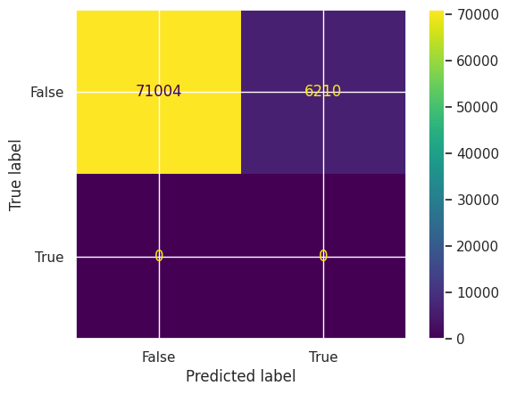

```python
y_predct = random_classifier_model.predict(x_test_fit)
accuracy = sklearn.metrics.accuracy_score(y_predct,y_test)
conf_mtrx = sklearn.metrics.confusion_matrix(y_predct,y_test)

precision,recall,fscore,support= sklearn.metrics.precision_recall_fscore_support(y_test,y_predct)
print("The Random Forest Classifier accuracy is",accuracy)
print("The Random Forest Classifier precision is",precision)
print("The  Random Forest Classifier recall is",recall)
print("The Random Forest Classifier fscore is",fscore)
print("The Random Forest Classifier confusion matrix is",conf_mtrx)


conf_matrix_display = metrics.ConfusionMatrixDisplay(confusion_matrix = conf_mtrx, display_labels = [False, True])
conf_matrix_display.plot()
plts.show()
```

## **Discussion and Conclusion**

The purpose of the Project has been to Evaluate various categorical and Numerical Values and if they cause A positive or negative heartdisease in a sample of Patients .

The problem is a classification problem .

**Analysis Of Logistic Regression**

A most commonly used approach in Classification problem is Logistic Regression. A Target Variable in this case is Heart Disease , there are Independant and dependant Variable . As it can be seen the accuracy of the predicted model is higher using hyperparamtres 'newton-sg' ,penalty of l2 and max_iteration = 4000.

**Analysis Using Decision Tree Classifier**

Decision Tree Classifier is also a algorithm commonly used for Classification .

**Analysis Using Random Forest Classifier**

Random Forest classifier is also a commonly used classification algorithm.

**Conclusion**

Decision Tree classifier has several advantages as it averages all the predictions within the dataset .

Furtherly the dataset could be tested further by checking different target variables .

**If Hospitals can use existing data the possibilty is there that Patients could be better guided and heart disease that is a massive concern for an Individual can be avoided with good routine and good eating patterns**

# **The Link for the DataSet is as follows :**

**https://www.kaggle.com/datasets/alphiree/cardiovascular-diseases-risk-prediction-dataset**

# The Link for the Github is as follows :

**https://github.com/rafiaw01/M606-Machine-Learning-**